# Questionnaire Data Analysis

### 5.1.4. Results of WSAS-scores

#### 5.1.4.1 Regular LMM

```r
library(lme4)
library(lmerTest)

# Fitting the model
LMM_WSAS <- lmer(WSAS_total ~ treatment + time +  treatment:time +  ( 1|ID_reg),
               data = test_data,
               REML = T)


# Results of LMM
summary(LMM_WSAS)
```

```
## Linear mixed model fit by REML. t-tests use Satterthwaite's method [
## lmerModLmerTest]
## Formula: WSAS_total ~ treatment + time + treatment:time + (1 | ID_reg)
##    Data: test_data
##
## REML criterion at convergence: 545.7
##
## Scaled residuals:
##      Min       1Q   Median       3Q      Max
## -1.94961 -0.29631 -0.08652  0.27864  2.00919
##
## Random effects:
##  Groups   Name        Variance Std.Dev.
##  ID_reg   (Intercept) 47.63    6.901
##  Residual             18.65    4.318
## Number of obs: 84, groups:  ID_reg, 42
##
## Fixed effects:
##                    Estimate Std. Error         df t value Pr(>|t|)
## (Intercept)       1.776e+01  1.777e+00  5.276e+01   9.998 8.91e-14 ***
## treatment1        9.437e-14  2.512e+00  5.276e+01   0.000  1.00000
## time1            -2.000e+00  1.333e+00  4.000e+01  -1.501  0.14127
## treatment1:time1 -6.095e+00  1.885e+00  4.000e+01  -3.234  0.00245 **
## ---
## Signif. codes:  0 '***' 0.001 '**' 0.01 '*' 0.05 '.' 0.1 ' ' 1
##
## Correlation of Fixed Effects:
##             (Intr) trtmn1 time1
## treatment1  -0.707
## time1       -0.375  0.265
## trtmnt1:tm1  0.265 -0.375 -0.707
```

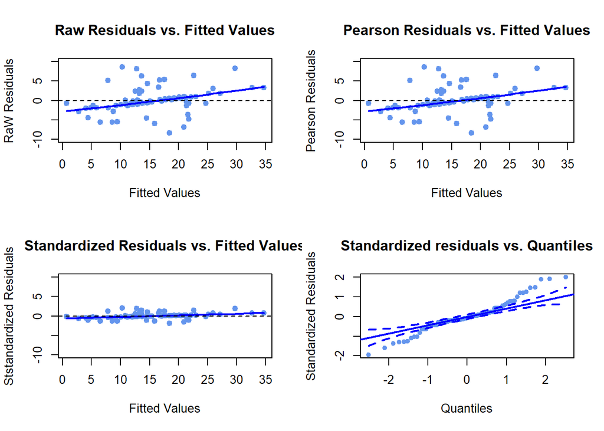

```r
library(car)
par(mfrow=c(2,2))

### Equal Variance Assumption ###

## 1. Raw Residuals vs. Fitted values
plot(resid(LMM_WSAS, type = "response") ~ fitted(LMM_WSAS),
    main = "Raw Residuals vs. Fitted Values",
     ylab = "RaW Residuals",
     ylim = c(-10, 10),
     xlab = "Fitted Values",
     pch = 19,
     col = "cornflowerblue")
lines(lowess(fitted(LMM_WSAS), resid(LMM_WSAS, type = "response")),
      col = "blue", lwd = 2)
abline(h = 0, col = "black", lty = 2)

## 2. Pearson Residuals vs. Fitted values
plot(resid(LMM_WSAS, type = "pearson") ~ fitted(LMM_WSAS),
    main = "Pearson Residuals vs. Fitted Values",
     ylab = "Pearson Residuals",
     ylim = c(-10, 10),
     xlab = "Fitted Values",
     pch = 19,
     col = "cornflowerblue")
lines(lowess(fitted(LMM_WSAS), resid(LMM_WSAS, type = "pearson")),
      col = "blue", lwd = 2)
abline(h = 0, col = "black", lty = 2)

## 3. Standardized Residuals vs. Fitted values
plot(resid(LMM_WSAS, scaled = T) ~ fitted(LMM_WSAS),
     main = "Standardized Residuals vs. Fitted Values",
     ylab = "Ststandardized Residuals",
     ylim = c(-10, 10),
     xlab = "Fitted Values",
     pch = 19,
     col = "cornflowerblue")
lines(lowess(fitted(LMM_WSAS), resid(LMM_WSAS, scaled = T)),
      col = "blue", lwd = 2)
abline(h = 0, col = "black", lty = 2)


### Normally Distributed Residuals Assumption ###

## 1. QQ-plot of the standardized residuals
qqPlot(resid(LMM_WSAS, scaled = T),
       main = "Standardized residuals vs. Quantiles",
       ylab = "Standardized Residuals",
       xlab = "Quantiles",
       pch = 19,
       col = "cornflowerblue",
       grid = F,
       id = F,
       envelope = list(style = "lines"))
```

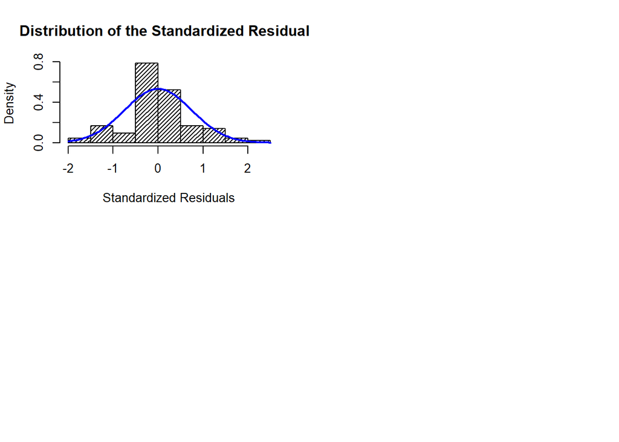

```r
## 2. Histogram of the standardized residuals
hist(resid(LMM_WSAS, scaled = T),
     density = 30, col = "black",
     main = "Distribution of the Standardized Residuals",
     xlab = "Standardized Residuals",
     prob = T)
curve(dnorm(x, mean = mean(resid(LMM_WSAS, scaled = T)),
            sd = sd(resid(LMM_WSAS, scaled = T))),
      col = "blue", lwd = 2, add = T, yaxt="n")
```

We see that the distribution has both right- and left-skew and the distribution is peaked. Therefore, robust LMM was also performed to compare the estimates.

#### 5.1.4.2: Robust LMM

```r
library(robustlmm)
rLMM_WSAS <- rlmer(WSAS_total ~ treatment + time +  treatment:time + (1|ID_reg),
                  data = test_data)

summary(rLMM_WSAS)
```

```
## Robust linear mixed model fit by DAStau
## Formula: WSAS_total ~ treatment + time + treatment:time + (1 | ID_reg)
##    Data: test_data
##
## Scaled residuals:
##     Min      1Q  Median      3Q     Max
## -3.0200 -0.2240 -0.0048  0.2254  4.7509
##
## Random effects:
##  Groups   Name        Variance Std.Dev.
##  ID_reg   (Intercept) 53.194   7.293
##  Residual              6.087   2.467
## Number of obs: 84, groups: ID_reg, 42
##
## Fixed effects:
##                  Estimate Std. Error t value
## (Intercept)       17.2186     1.7232   9.992
## treatment1         0.2320     2.4370   0.095
## time1             -2.0000     0.7809  -2.561
## treatment1:time1  -6.4743     1.1044  -5.862
##
## Correlation of Fixed Effects:
##             (Intr) trtmn1 time1
## treatment1  -0.707
## time1       -0.227  0.160
## trtmnt1:tm1  0.160 -0.227 -0.707
##
## Robustness weights for the residuals:
##  68 weights are ~= 1. The remaining 16 ones are summarized as
##    Min. 1st Qu.  Median    Mean 3rd Qu.    Max.
##   0.283   0.423   0.540   0.580   0.741   0.989
##
## Robustness weights for the random effects:
##  33 weights are ~= 1. The remaining 9 ones are
##     1     3    12    13    21    22    24    33    34
## 0.906 0.485 0.866 0.906 0.866 0.973 0.865 0.969 0.973
##
## Rho functions used for fitting:
##   Residuals:
##     eff: smoothed Huber (k = 1.345, s = 10)
##     sig: smoothed Huber, Proposal 2 (k = 1.345, s = 10)
##   Random Effects, variance component 1 (ID_reg):
##     eff: smoothed Huber (k = 1.345, s = 10)
##     vcp: smoothed Huber, Proposal 2 (k = 1.345, s = 10)
```

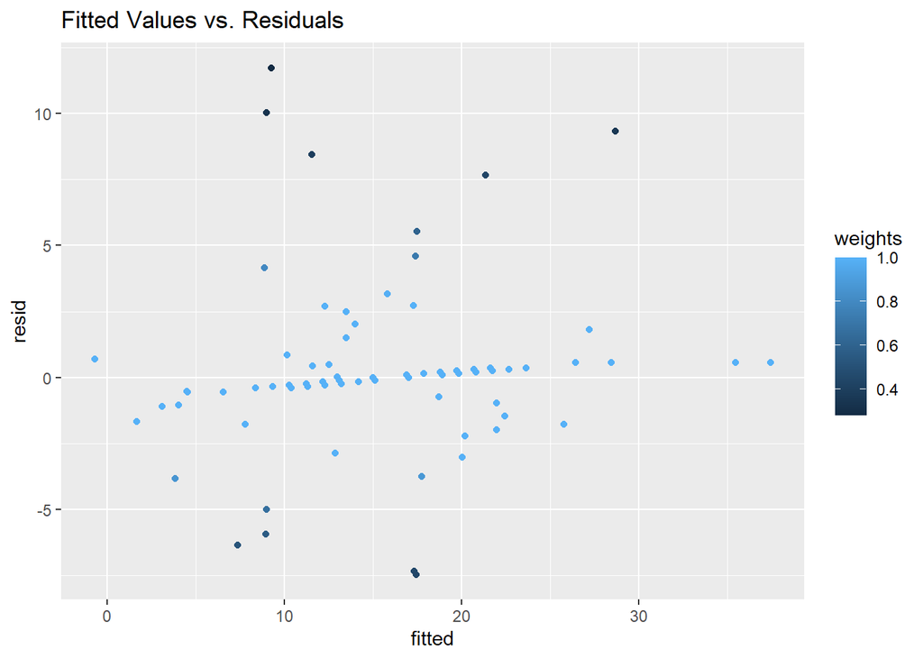

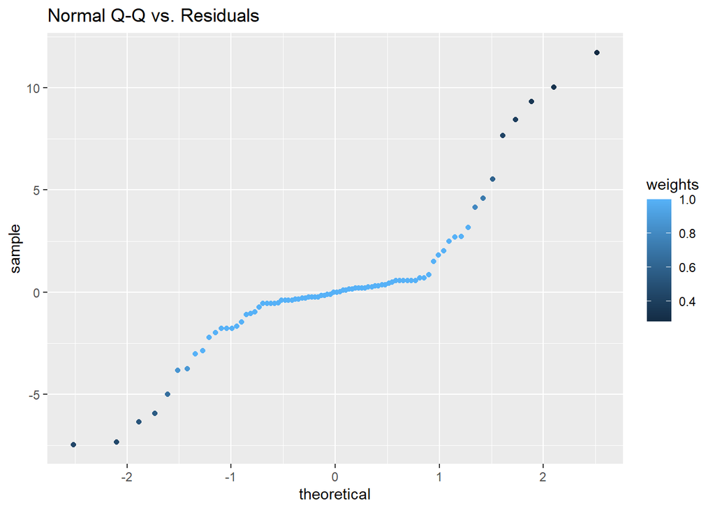

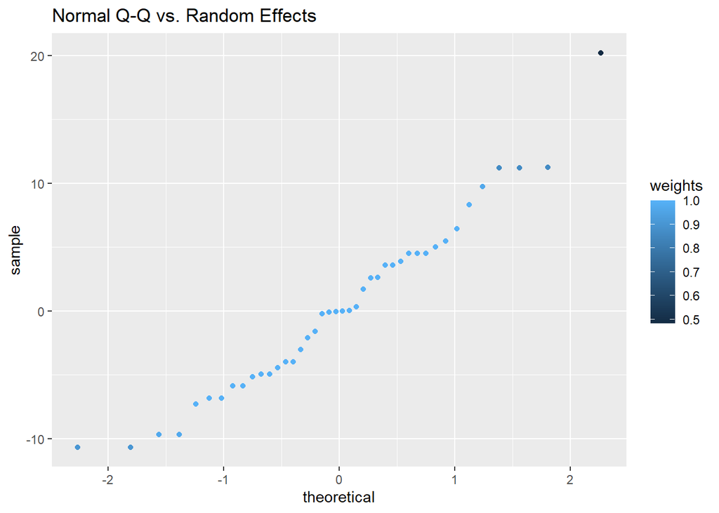

```r
# Plotting the robust LMM results
plot(rLMM_WSAS)
```

```r
# Comparing Regular LMM and robust LMM estimates for WSAS
compare(LMM_WSAS, rLMM_WSAS)
```

```
##                      LMM_WSAS
## Coef
## (Intercept)           1.78e+01 (1.78)
## treatment1            9.44e-14 (2.51)
## time1                -2.00e+00 (1.33)
## treatment1:time1     -6.10e+00 (1.88)
##
## VarComp
## (Intercept) | ID_reg 6.90
##
## sigma                4.32
##
## REML                 546
## rho.e
## rho.sigma.e
## rho.b_1
## rho.sigma.b_1
##                      rLMM_WSAS
## Coef
## (Intercept)          17.219 (1.723)
## treatment1            0.232 (2.437)
## time1                -2.000 (0.781)
## treatment1:time1     -6.474 (1.104)
##
## VarComp
## (Intercept) | ID_reg 7.29
##
## sigma                2.47
##
## REML
## rho.e                smoothed Huber (k = 1.345, s = 10)
## rho.sigma.e          smoothed Huber, Proposal 2 (k = 1.345, s = 10)
## rho.b_1              smoothed Huber (k = 1.345, s = 10)
## rho.sigma.b_1        smoothed Huber, Proposal 2 (k = 1.345, s = 10)
```

We can see that the estimates are quite close to another so it can be assumed that the results of regular LMM aren’t very biased even if residuals have heavy tails.

### 5.1.5 Results of MHQol-Scores

```r
library(lme4)
library(lmerTest)

LMM_MHQol <- lmer(MHQol_total ~ treatment + time +  treatment:time
                  +  ( 1|ID_reg),
               data = test_data,
               REML = T)


# Results of LMM
summary(LMM_MHQol)
```

```
## Linear mixed model fit by REML. t-tests use Satterthwaite's method [
## lmerModLmerTest]
## Formula: MHQol_total ~ treatment + time + treatment:time + (1 | ID_reg)
##    Data: test_data
##
## REML criterion at convergence: 351.7
##
## Scaled residuals:
##     Min      1Q  Median      3Q     Max
## -2.2890 -0.4744  0.0409  0.3844  1.7482
##
## Random effects:
##  Groups   Name        Variance Std.Dev.
##  ID_reg   (Intercept) 3.125    1.768
##  Residual             2.015    1.420
## Number of obs: 84, groups:  ID_reg, 42
##
## Fixed effects:
##                    Estimate Std. Error         df t value Pr(>|t|)
## (Intercept)       2.076e+01  4.948e-01  5.841e+01  41.964  < 2e-16 ***
## treatment1       -1.313e-13  6.997e-01  5.841e+01   0.000    1.000
## time1            -2.000e+00  4.381e-01  4.000e+01  -4.565 4.68e-05 ***
## treatment1:time1  4.762e-01  6.196e-01  4.000e+01   0.769    0.447
## ---
## Signif. codes:  0 '***' 0.001 '**' 0.01 '*' 0.05 '.' 0.1 ' ' 1
##
## Correlation of Fixed Effects:
##             (Intr) trtmn1 time1
## treatment1  -0.707
## time1       -0.443  0.313
## trtmnt1:tm1  0.313 -0.443 -0.707
```

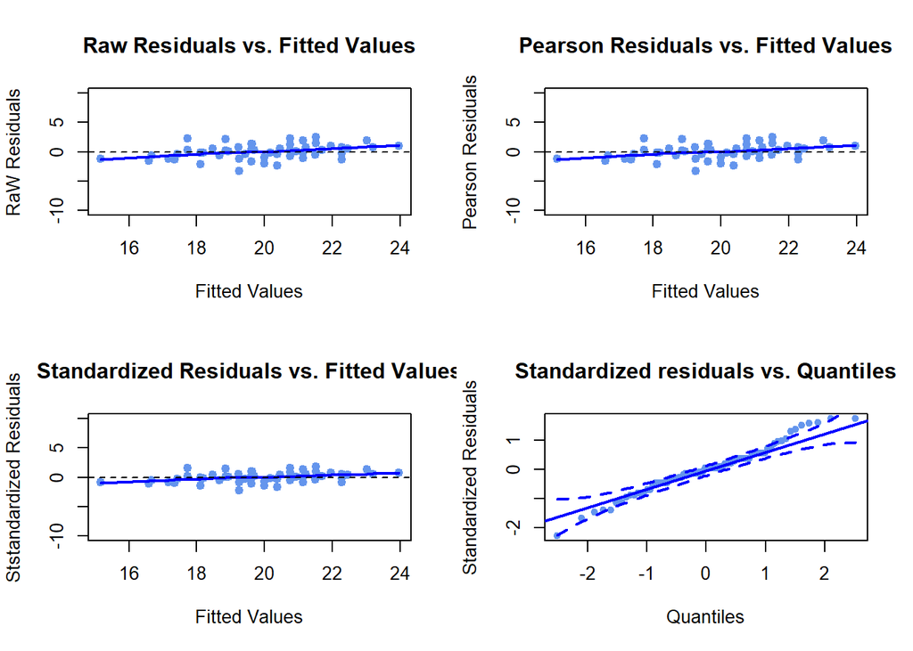

```r
library(car)
par(mfrow=c(2,2))

### Equal Variance Assumption ###

## 1. Raw Residuals vs. Fitted values
plot(resid(LMM_MHQol, type = "response") ~ fitted(LMM_MHQol),
    main = "Raw Residuals vs. Fitted Values",
     ylab = "RaW Residuals",
     ylim = c(-10, 10),
     xlab = "Fitted Values",
     pch = 19,
     col = "cornflowerblue")
lines(lowess(fitted(LMM_MHQol), resid(LMM_MHQol, type = "response")),
      col = "blue", lwd = 2)
abline(h = 0, col = "black", lty = 2)

## 2. Pearson Residuals vs. Fitted values
plot(resid(LMM_MHQol, type = "pearson") ~ fitted(LMM_MHQol),
    main = "Pearson Residuals vs. Fitted Values",
     ylab = "Pearson Residuals",
     ylim = c(-10, 10),
     xlab = "Fitted Values",
     pch = 19,
     col = "cornflowerblue")
lines(lowess(fitted(LMM_MHQol), resid(LMM_MHQol, type = "pearson")),
      col = "blue", lwd = 2)
abline(h = 0, col = "black", lty = 2)

## 3. Standardized Residuals vs. Fitted values
plot(resid(LMM_MHQol, scaled = T) ~ fitted(LMM_MHQol),
     main = "Standardized Residuals vs. Fitted Values",
     ylab = "Ststandardized Residuals",
     ylim = c(-10, 10),
     xlab = "Fitted Values",
     pch = 19,
     col = "cornflowerblue")
lines(lowess(fitted(LMM_MHQol), resid(LMM_MHQol, scaled = T)),
      col = "blue", lwd = 2)
abline(h = 0, col = "black", lty = 2)


### Normally Distributed Residuals Assumption ###

## 1. QQ-plot of the standardized residuals
qqPlot(resid(LMM_MHQol, scaled = T),
       main = "Standardized residuals vs. Quantiles",
       ylab = "Standardized Residuals",
       xlab = "Quantiles",
       pch = 19,
       col = "cornflowerblue",
       grid = F,
       id = F,
       envelope = list(style = "lines"))
```

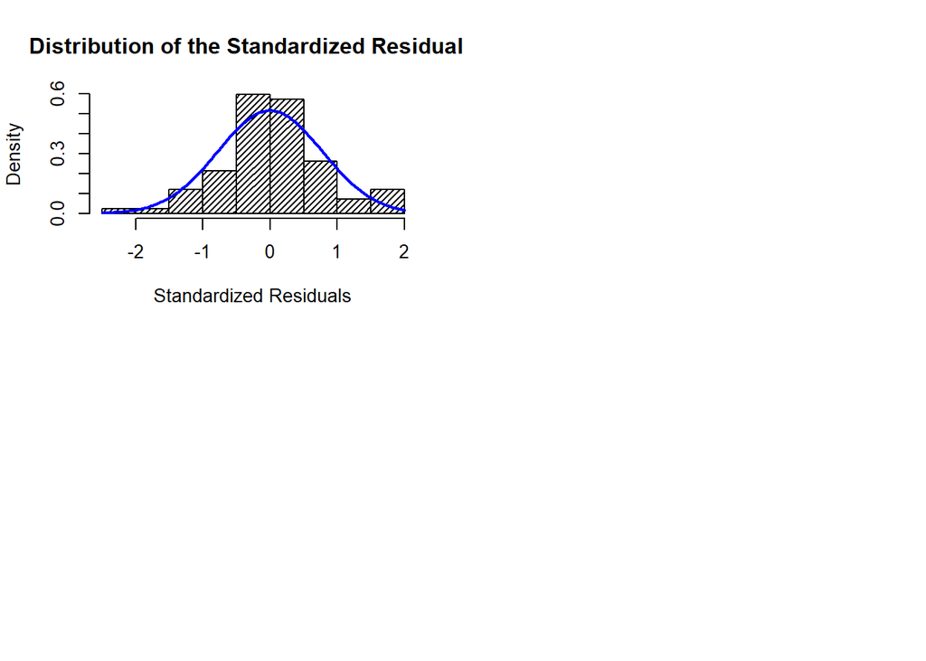

```r
## 2. Histogram of the standardized residuals
hist(resid(LMM_MHQol, scaled = T),
     density = 30, col = "black",
     main = "Distribution of the Standardized Residuals",
     xlab = "Standardized Residuals",
     prob = T)
curve(dnorm(x, mean = mean(resid(LMM_MHQol, scaled = T)),
            sd = sd(resid(LMM_MHQol, scaled = T))),
      col = "blue", lwd = 2, add = T, yaxt="n")
```

Residuals are slightly right-skewed but the distribution shows that they are approximately normally distributed.

### 5.1.6 Results for MCTQ: Average weekly sleep duration (SDweek)

```r
# Change MCTQ variable to minutes
test_data$mctq_SDweek <- as.numeric(test_data$mctq_SDweek) / 60
test_data$mctq_SLossWeek <- as.numeric(test_data$mctq_SLossWeek) / 60
test_data$mctq_SJL <- as.numeric(test_data$mctq_SJL) / 60
```

#### 5.1.6.1 Regular LMM

```r
library(lme4)
library(lmerTest)

LMM_mctq_SDweek <- lmer(as.numeric(mctq_SDweek) ~ treatment + time +  treatment:time
                     +  ( 1|ID_reg),
               data = test_data,
               REML = T)


# Results of LMM
summary(LMM_mctq_SDweek)
```

```
## Linear mixed model fit by REML. t-tests use Satterthwaite's method [
## lmerModLmerTest]
## Formula: as.numeric(mctq_SDweek) ~ treatment + time + treatment:time +
##     (1 | ID_reg)
##    Data: test_data
##
## REML criterion at convergence: 1119.5
##
## Scaled residuals:
##     Min      1Q  Median      3Q     Max
## -2.6657 -0.3815  0.1247  0.4518  1.7094
##
## Random effects:
##  Groups   Name        Variance Std.Dev.
##  ID_reg   (Intercept) 8161     90.34
##  Residual             7021     83.79
## Number of obs: 94, groups:  ID_reg, 48
##
## Fixed effects:
##                    Estimate Std. Error         df t value Pr(>|t|)
## (Intercept)       4.184e+02  2.515e+01  6.964e+01  16.635   <2e-16 ***
## treatment1        1.879e-12  3.557e+01  6.964e+01   0.000    1.000
## time1             2.469e+01  2.419e+01  4.320e+01   1.021    0.313
## treatment1:time1 -2.496e+01  3.480e+01  4.390e+01  -0.717    0.477
## ---
## Signif. codes:  0 '***' 0.001 '**' 0.01 '*' 0.05 '.' 0.1 ' ' 1
##
## Correlation of Fixed Effects:
##             (Intr) trtmn1 time1
## treatment1  -0.707
## time1       -0.481  0.340
## trtmnt1:tm1  0.334 -0.473 -0.695
```

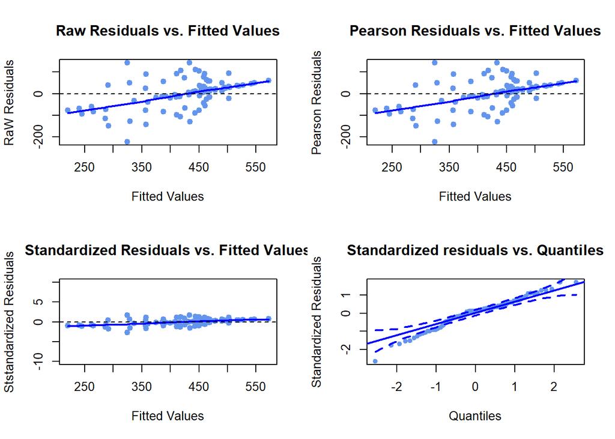

```r
library(car)
par(mfrow=c(2,2))

### Equal Variance Assumption ###

## 1. Raw Residuals vs. Fitted values
plot(resid(LMM_mctq_SDweek, type = "response") ~ fitted(LMM_mctq_SDweek),
    main = "Raw Residuals vs. Fitted Values",
     ylab = "RaW Residuals",
     xlab = "Fitted Values",
     pch = 19,
     col = "cornflowerblue")
lines(lowess(fitted(LMM_mctq_SDweek), resid(LMM_mctq_SDweek, type = "response")),
      col = "blue", lwd = 2)
abline(h = 0, col = "black", lty = 2)

## 2. Pearson Residuals vs. Fitted values
plot(resid(LMM_mctq_SDweek, type = "pearson") ~ fitted(LMM_mctq_SDweek),
    main = "Pearson Residuals vs. Fitted Values",
     ylab = "Pearson Residuals",
     xlab = "Fitted Values",
     pch = 19,
     col = "cornflowerblue")
lines(lowess(fitted(LMM_mctq_SDweek), resid(LMM_mctq_SDweek, type = "pearson")),
      col = "blue", lwd = 2)
abline(h = 0, col = "black", lty = 2)

## 3. Standardized Residuals vs. Fitted values
plot(resid(LMM_mctq_SDweek, scaled = T) ~ fitted(LMM_mctq_SDweek),
     main = "Standardized Residuals vs. Fitted Values",
     ylab = "Ststandardized Residuals",
     ylim = c(-10, 10),
     xlab = "Fitted Values",
     pch = 19,
     col = "cornflowerblue")
lines(lowess(fitted(LMM_mctq_SDweek), resid(LMM_mctq_SDweek, scaled = T)),
      col = "blue", lwd = 2)
abline(h = 0, col = "black", lty = 2)


### Normally Distributed Residuals Assumption ###

## 1. QQ-plot of the standardized residuals
qqPlot(resid(LMM_mctq_SDweek, scaled = T),
       main = "Standardized residuals vs. Quantiles",
       ylab = "Standardized Residuals",
       xlab = "Quantiles",
       pch = 19,
       col = "cornflowerblue",
       grid = F,
       id = F,
       envelope = list(style = "lines"))
```

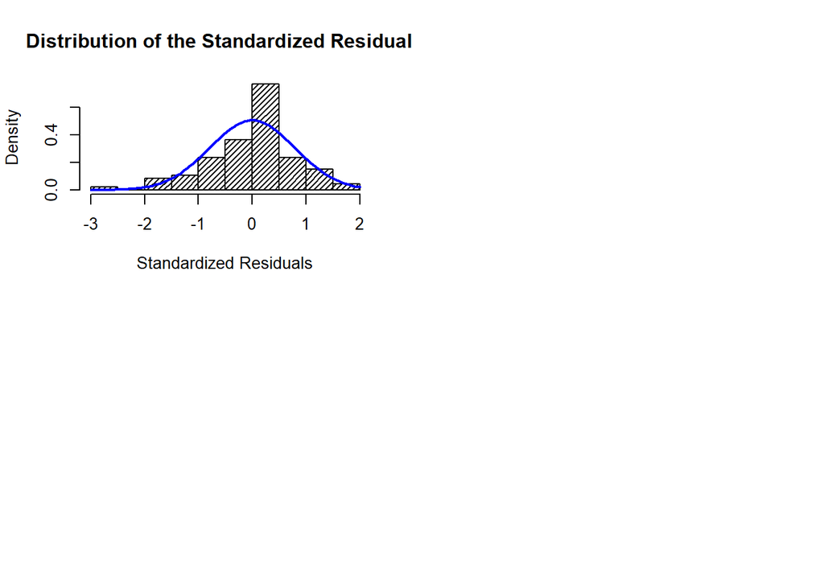

```r
## 2. Histogram of the standardized residuals
hist(resid(LMM_mctq_SDweek, scaled = T),
     density = 30, col = "black",
     main = "Distribution of the Standardized Residuals",
     xlab = "Standardized Residuals",
     prob = T)
curve(dnorm(x, mean = mean(resid(LMM_mctq_SDweek, scaled = T)),
            sd = sd(resid(LMM_mctq_SDweek, scaled = T))),
      col = "blue", lwd = 2, add = T, yaxt="n")
```

Residuals have a slight left-skew and the residuals are not equalyl distributed. Therefore, robust LMM was performed.

#### 5.1.6.2 Robust LMM

```r
library(robustlmm)
rLMM_mctq_SDweek <- rlmer(as.numeric(mctq_SDweek)  ~
                               treatment + time +  treatment:time + (1|ID_reg),
                  data = test_data)

summary(rLMM_mctq_SDweek)
```

```
## Robust linear mixed model fit by DAStau
## Formula: as.numeric(mctq_SDweek) ~ treatment + time + treatment:time +      (1 | ID_reg)
##    Data: test_data
##
## Scaled residuals:
##     Min      1Q  Median      3Q     Max
## -4.5773 -0.4607  0.0800  0.4305  2.1676
##
## Random effects:
##  Groups   Name        Variance Std.Dev.
##  ID_reg   (Intercept) 6301     79.38
##  Residual             4398     66.32
## Number of obs: 94, groups: ID_reg, 48
##
## Fixed effects:
##                  Estimate Std. Error t value
## (Intercept)        432.79      21.66  19.986
## treatment1          -6.19      30.62  -0.202
## time1               24.68      19.64   1.257
## treatment1:time1   -18.18      28.27  -0.643
##
## Correlation of Fixed Effects:
##             (Intr) trtmn1 time1
## treatment1  -0.707
## time1       -0.453  0.321
## trtmnt1:tm1  0.315 -0.445 -0.695
##
## Robustness weights for the residuals:
##  79 weights are ~= 1. The remaining 15 ones are summarized as
##    Min. 1st Qu.  Median    Mean 3rd Qu.    Max.
##   0.294   0.626   0.736   0.749   0.912   0.995
##
## Robustness weights for the random effects:
##  42 weights are ~= 1. The remaining 6 ones are
##     4     5    15    18    28    29
## 0.461 0.409 0.798 0.532 0.591 0.891
##
## Rho functions used for fitting:
##   Residuals:
##     eff: smoothed Huber (k = 1.345, s = 10)
##     sig: smoothed Huber, Proposal 2 (k = 1.345, s = 10)
##   Random Effects, variance component 1 (ID_reg):
##     eff: smoothed Huber (k = 1.345, s = 10)
##     vcp: smoothed Huber, Proposal 2 (k = 1.345, s = 10)
```

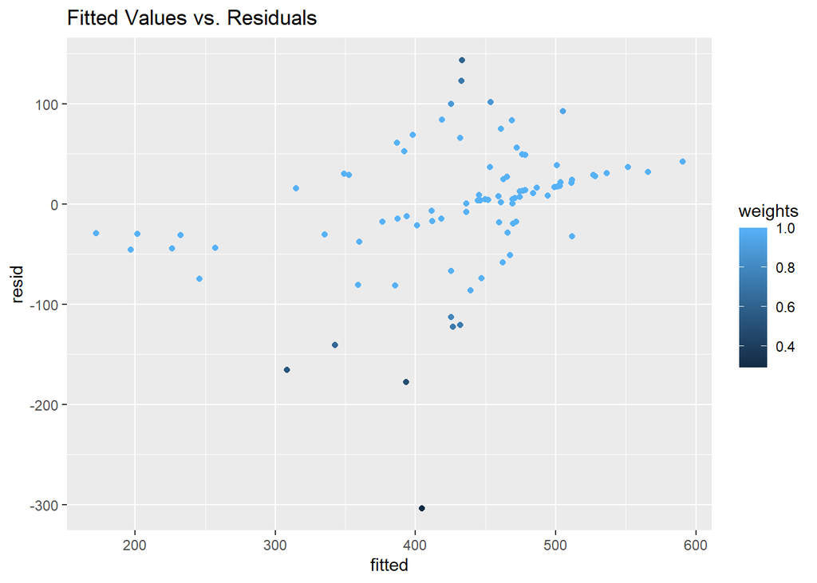

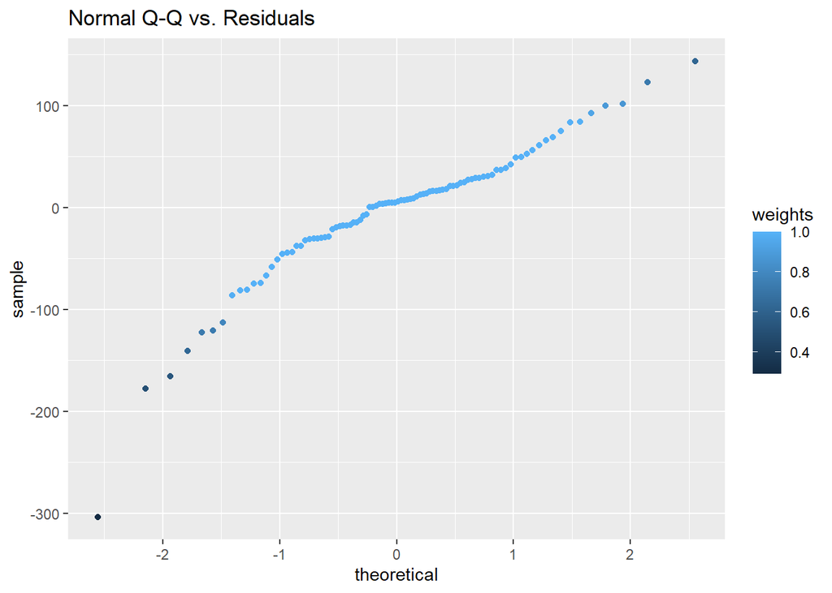

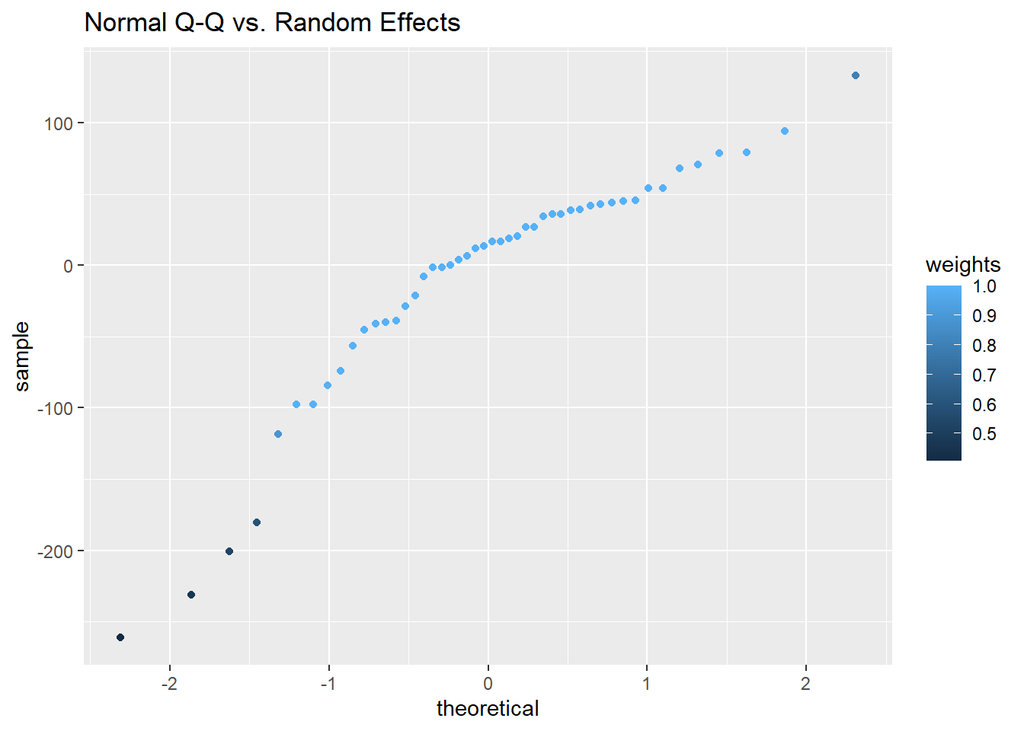

```r
plot(rLMM_mctq_SDweek)
```

```r
compare(LMM_mctq_SDweek, rLMM_mctq_SDweek)
```

```
##                      LMM_mctq_SDweek
## Coef
## (Intercept)           4.18e+02 (25.2)
## treatment1            1.88e-12 (35.6)
## time1                 2.47e+01 (24.2)
## treatment1:time1     -2.50e+01 (34.8)
##
## VarComp
## (Intercept) | ID_reg 90.3
##
## sigma                83.8
##
## REML                 1120
## rho.e
## rho.sigma.e
## rho.b_1
## rho.sigma.b_1
##                      rLMM_mctq_SDweek
## Coef
## (Intercept)          432.79 (21.7)
## treatment1            -6.19 (30.6)
## time1                 24.69 (19.6)
## treatment1:time1     -18.18 (28.3)
##
## VarComp
## (Intercept) | ID_reg 79.4
##
## sigma                66.3
##
## REML
## rho.e                smoothed Huber (k = 1.345, s = 10)
## rho.sigma.e          smoothed Huber, Proposal 2 (k = 1.345, s = 10)
## rho.b_1              smoothed Huber (k = 1.345, s = 10)
## rho.sigma.b_1        smoothed Huber, Proposal 2 (k = 1.345, s = 10)
```

The estimates for the treatment effect and and the interaction vary slightly more and the others.

### 5.1.7: Result for MCTQ: Weekly Sleep Loss (SLossWeek)

#### 5.1.7.1 Regular LMM

```r
library(lme4)
library(lmerTest)

LMM_data <- df_questionnaire_data[!is.na(df_questionnaire_data$mctq_SLossWeek),]

LMM_mctq_SLossWeek <- lmer(sqrt(as.numeric(mctq_SLossWeek)) ~ treatment + time
                           +  treatment:time +  ( 1|ID_reg),
               data = test_data,
               REML = T)


# Results of LMM
summary(LMM_mctq_SLossWeek)
```

```
## Linear mixed model fit by REML. t-tests use Satterthwaite's method [
## lmerModLmerTest]
## Formula:
## sqrt(as.numeric(mctq_SLossWeek)) ~ treatment + time + treatment:time +
##     (1 | ID_reg)
##    Data: test_data
##
## REML criterion at convergence: 568.9
##
## Scaled residuals:
##      Min       1Q   Median       3Q      Max
## -2.01079 -0.48723 -0.00059  0.33234  2.47928
##
## Random effects:
##  Groups   Name        Variance Std.Dev.
##  ID_reg   (Intercept) 15.58    3.948
##  Residual             16.66    4.082
## Number of obs: 94, groups:  ID_reg, 48
##
## Fixed effects:
##                    Estimate Std. Error         df t value Pr(>|t|)
## (Intercept)       9.264e+00  1.159e+00  7.216e+01   7.992 1.56e-11 ***
## treatment1       -4.201e-14  1.639e+00  7.216e+01   0.000  1.00000
## time1            -2.346e-01  1.178e+00  4.224e+01  -0.199  0.84316
## treatment1:time1 -4.937e+00  1.694e+00  4.299e+01  -2.914  0.00564 **
## ---
## Signif. codes:  0 '***' 0.001 '**' 0.01 '*' 0.05 '.' 0.1 ' ' 1
##
## Correlation of Fixed Effects:
##             (Intr) trtmn1 time1
## treatment1  -0.707
## time1       -0.508  0.359
## trtmnt1:tm1  0.353 -0.500 -0.695
```

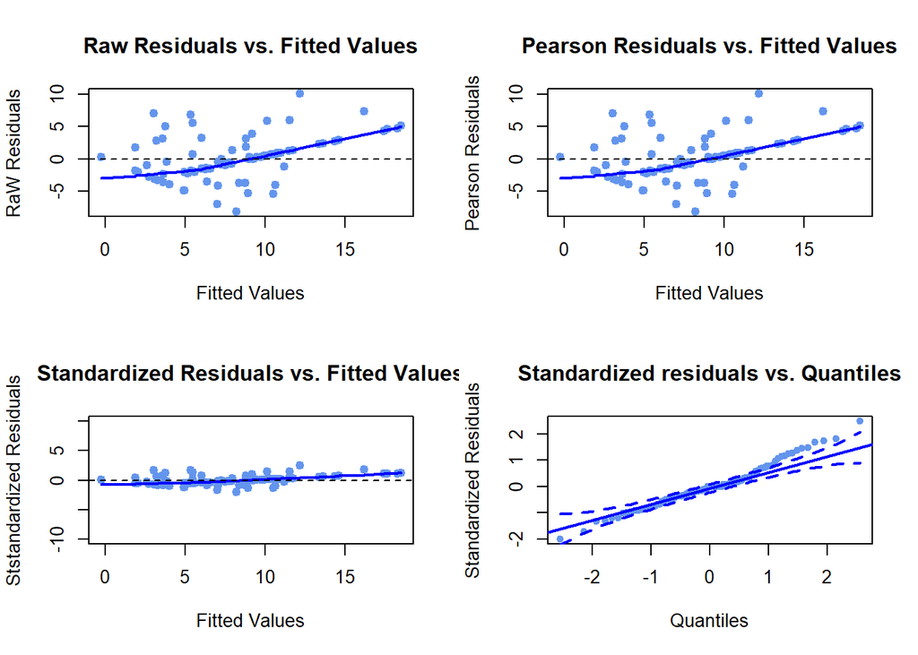

```r
library(car)
par(mfrow=c(2,2))

### Equal Variance Assumption ###

## 1. Raw Residuals vs. Fitted values
plot(resid(LMM_mctq_SLossWeek, type = "response") ~ fitted(LMM_mctq_SLossWeek),
    main = "Raw Residuals vs. Fitted Values",
     ylab = "RaW Residuals",
     xlab = "Fitted Values",
     pch = 19,
     col = "cornflowerblue")
lines(lowess(fitted(LMM_mctq_SLossWeek), resid(LMM_mctq_SLossWeek,
                                               type = "response")),
      col = "blue", lwd = 2)
abline(h = 0, col = "black", lty = 2)

## 2. Pearson Residuals vs. Fitted values
plot(resid(LMM_mctq_SLossWeek, type = "pearson") ~ fitted(LMM_mctq_SLossWeek),
    main = "Pearson Residuals vs. Fitted Values",
     ylab = "Pearson Residuals",
     xlab = "Fitted Values",
     pch = 19,
     col = "cornflowerblue")
lines(lowess(fitted(LMM_mctq_SLossWeek), resid(LMM_mctq_SLossWeek,
                                               type = "pearson")),
      col = "blue", lwd = 2)
abline(h = 0, col = "black", lty = 2)

## 3. Standardized Residuals vs. Fitted values
plot(resid(LMM_mctq_SLossWeek, scaled = T) ~ fitted(LMM_mctq_SLossWeek),
     main = "Standardized Residuals vs. Fitted Values",
     ylab = "Ststandardized Residuals",
     ylim = c(-10, 10),
     xlab = "Fitted Values",
     pch = 19,
     col = "cornflowerblue")
lines(lowess(fitted(LMM_mctq_SLossWeek), resid(LMM_mctq_SLossWeek, scaled = T)),
      col = "blue", lwd = 2)
abline(h = 0, col = "black", lty = 2)


### Normally Distributed Residuals Assumption ###

## 1. QQ-plot of the standardized residuals
qqPlot(resid(LMM_mctq_SLossWeek, scaled = T),
       main = "Standardized residuals vs. Quantiles",
       ylab = "Standardized Residuals",
       xlab = "Quantiles",
       pch = 19,
       col = "cornflowerblue",
       grid = F,
       id = F,
       envelope = list(style = "lines"))
```

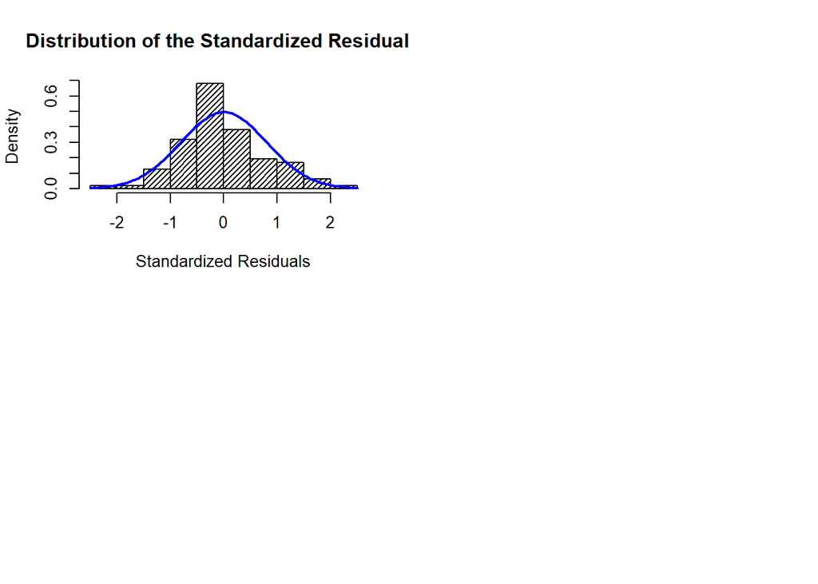

```r
## 2. Histogram of the standardized residuals
hist(resid(LMM_mctq_SLossWeek, scaled = T),
     density = 30, col = "black",
     main = "Distribution of the Standardized Residuals",
     xlab = "Standardized Residuals",
     prob = T)
curve(dnorm(x, mean = mean(resid(LMM_mctq_SLossWeek, scaled = T)),
            sd = sd(resid(LMM_mctq_SLossWeek, scaled = T))),
      col = "blue", lwd = 2, add = T, yaxt="n")
```

The transformed data still violates the equal variance assumption so robust LMM was performed.

#### 5.1.7.2 Robust LMM

```r
library(robustlmm)
rLMM_mctq_SLossWeek <- rlmer(sqrt(as.numeric(mctq_SLossWeek))  ~
                               treatment + time +  treatment:time + (1|ID_reg),
                  data = test_data)

summary(rLMM_mctq_SLossWeek)
```

```
## Robust linear mixed model fit by DAStau
## Formula: sqrt(as.numeric(mctq_SLossWeek)) ~ treatment + time + treatment:time +      (1 | ID_reg)
##    Data: test_data
##
## Scaled residuals:
##      Min       1Q   Median       3Q      Max
## -1.66576 -0.70283  0.05032  0.57090  2.84899
##
## Random effects:
##  Groups   Name        Variance Std.Dev.
##  ID_reg   (Intercept)  0.00    0.000
##  Residual             27.33    5.228
## Number of obs: 94, groups: ID_reg, 48
##
## Fixed effects:
##                    Estimate Std. Error t value
## (Intercept)       8.709e+00  1.095e+00   7.957
## treatment1       -3.739e-12  1.548e+00   0.000
## time1            -2.034e-01  1.548e+00  -0.131
## treatment1:time1 -4.819e+00  2.214e+00  -2.177
##
## Correlation of Fixed Effects:
##             (Intr) trtmn1 time1
## treatment1  -0.707
## time1       -0.707  0.500
## trtmnt1:tm1  0.494 -0.699 -0.699
##
## Robustness weights for the residuals:
##  74 weights are ~= 1. The remaining 20 ones are summarized as
##    Min. 1st Qu.  Median    Mean 3rd Qu.    Max.
##   0.472   0.528   0.804   0.742   0.823   0.956
##
## Robustness weights for the random effects:
##  All 48 weights are ~= 1.
##
## Rho functions used for fitting:
##   Residuals:
##     eff: smoothed Huber (k = 1.345, s = 10)
##     sig: smoothed Huber, Proposal 2 (k = 1.345, s = 10)
##   Random Effects, variance component 1 (ID_reg):
##     eff: smoothed Huber (k = 1.345, s = 10)
##     vcp: smoothed Huber, Proposal 2 (k = 1.345, s = 10)
```

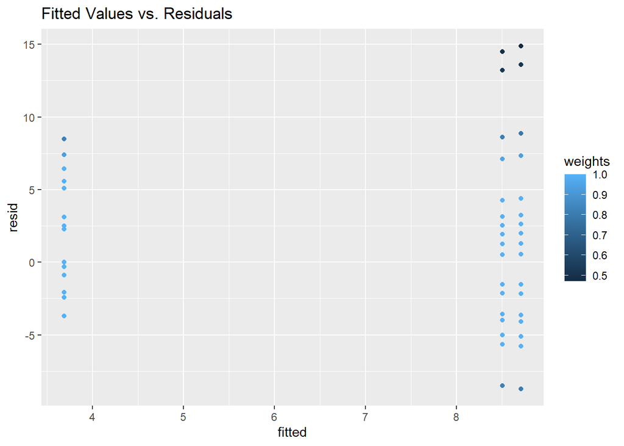

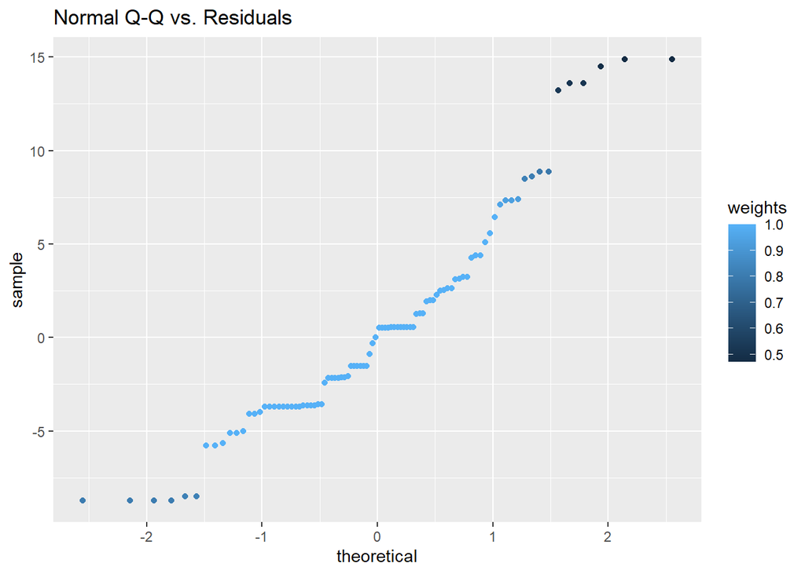

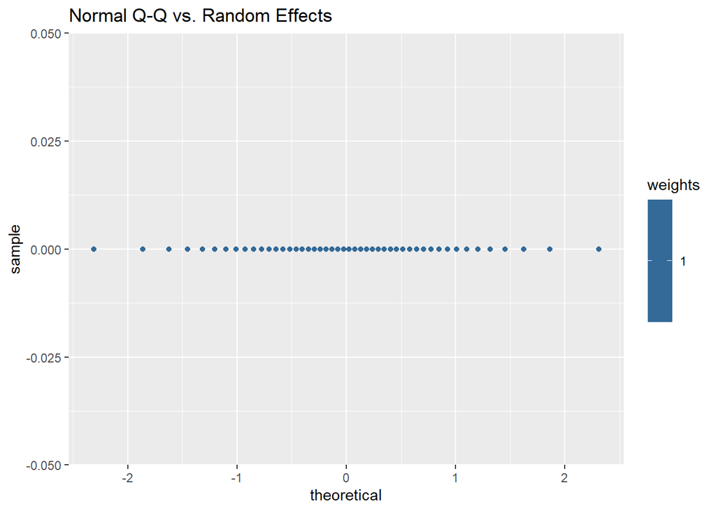

```r
plot(rLMM_mctq_SLossWeek)
```

```r
# Comparing Regular LMM and robust LMM estimates for WSAS
compare(LMM_mctq_SLossWeek, rLMM_mctq_SLossWeek)
```

```
##                      LMM_mctq_SLossWeek
## Coef
## (Intercept)           9.26e+00 (1.16)
## treatment1           -4.20e-14 (1.64)
## time1                -2.35e-01 (1.18)
## treatment1:time1     -4.94e+00 (1.69)
##
## VarComp
## (Intercept) | ID_reg 3.95
##
## sigma                4.08
##
## REML                 569
## rho.e
## rho.sigma.e
## rho.b_1
## rho.sigma.b_1
##                      rLMM_mctq_SLossWeek
## Coef
## (Intercept)           8.71e+00 (1.09)
## treatment1           -3.74e-12 (1.55)
## time1                -2.03e-01 (1.55)
## treatment1:time1     -4.82e+00 (2.21)
##
## VarComp
## (Intercept) | ID_reg 0.00
##
## sigma                5.23
##
## REML
## rho.e                smoothed Huber (k = 1.345, s = 10)
## rho.sigma.e          smoothed Huber, Proposal 2 (k = 1.345, s = 10)
## rho.b_1              smoothed Huber (k = 1.345, s = 10)
## rho.sigma.b_1        smoothed Huber, Proposal 2 (k = 1.345, s = 10)
```

We can see that the regular LMM and robust LMM estimates are close to one another.

### 5.1.8 Results for MCTQ: Social Jetlag

```r
library(lme4)
library(lmerTest)

LMM_mctq_SJL <- lmer(as.numeric(mctq_SJL) ~ treatment + time +  treatment:time
                     +  ( 1|ID_reg),
               data = test_data,
               REML = T)


# Results of LMM
summary(LMM_mctq_SJL)
```

```
## Linear mixed model fit by REML. t-tests use Satterthwaite's method [
## lmerModLmerTest]
## Formula: as.numeric(mctq_SJL) ~ treatment + time + treatment:time + (1 |
##     ID_reg)
##    Data: test_data
##
## REML criterion at convergence: 995.1
##
## Scaled residuals:
##     Min      1Q  Median      3Q     Max
## -1.8529 -0.4006 -0.0299  0.3631  3.4175
##
## Random effects:
##  Groups   Name        Variance Std.Dev.
##  ID_reg   (Intercept) 1630     40.38
##  Residual             1657     40.71
## Number of obs: 95, groups:  ID_reg, 48
##
## Fixed effects:
##                   Estimate Std. Error        df t value Pr(>|t|)
## (Intercept)      6.323e+01  1.170e+01 7.347e+01   5.402 7.78e-07 ***
## treatment1       3.407e-13  1.655e+01 7.347e+01   0.000   1.0000
## time1            3.731e+00  1.175e+01 4.544e+01   0.317   0.7524
## treatment1:time1 3.648e+01  1.676e+01 4.581e+01   2.177   0.0347 *
## ---
## Signif. codes:  0 '***' 0.001 '**' 0.01 '*' 0.05 '.' 0.1 ' ' 1
##
## Correlation of Fixed Effects:
##             (Intr) trtmn1 time1
## treatment1  -0.707
## time1       -0.502  0.355
## trtmnt1:tm1  0.352 -0.498 -0.701
```

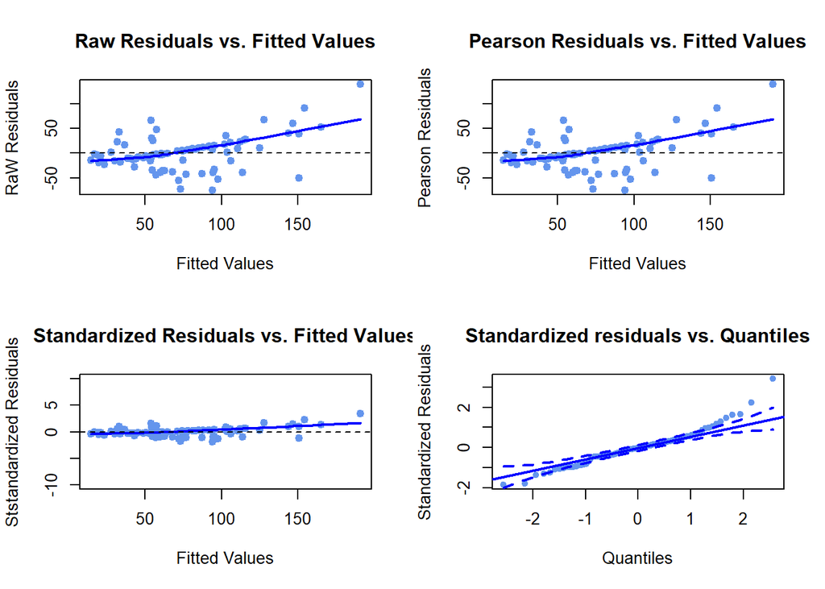

```r
library(car)
par(mfrow=c(2,2))

### Equal Variance Assumption ###

## 1. Raw Residuals vs. Fitted values
plot(resid(LMM_mctq_SJL, type = "response") ~ fitted(LMM_mctq_SJL),
    main = "Raw Residuals vs. Fitted Values",
     ylab = "RaW Residuals",
     xlab = "Fitted Values",
     pch = 19,
     col = "cornflowerblue")
lines(lowess(fitted(LMM_mctq_SJL), resid(LMM_mctq_SJL, type = "response")),
      col = "blue", lwd = 2)
abline(h = 0, col = "black", lty = 2)

## 2. Pearson Residuals vs. Fitted values
plot(resid(LMM_mctq_SJL, type = "pearson") ~ fitted(LMM_mctq_SJL),
    main = "Pearson Residuals vs. Fitted Values",
     ylab = "Pearson Residuals",
     xlab = "Fitted Values",
     pch = 19,
     col = "cornflowerblue")
lines(lowess(fitted(LMM_mctq_SJL), resid(LMM_mctq_SJL, type = "pearson")),
      col = "blue", lwd = 2)
abline(h = 0, col = "black", lty = 2)

## 3. Standardized Residuals vs. Fitted values
plot(resid(LMM_mctq_SJL, scaled = T) ~ fitted(LMM_mctq_SJL),
     main = "Standardized Residuals vs. Fitted Values",
     ylab = "Ststandardized Residuals",
     ylim = c(-10, 10),
     xlab = "Fitted Values",
     pch = 19,
     col = "cornflowerblue")
lines(lowess(fitted(LMM_mctq_SJL), resid(LMM_mctq_SJL, scaled = T)),
      col = "blue", lwd = 2)
abline(h = 0, col = "black", lty = 2)


### Normally Distributed Residuals Assumption ###

## 1. QQ-plot of the standardized residuals
qqPlot(resid(LMM_mctq_SJL, scaled = T),
       main = "Standardized residuals vs. Quantiles",
       ylab = "Standardized Residuals",
       xlab = "Quantiles",
       pch = 19,
       col = "cornflowerblue",
       grid = F,
       id = F,
       envelope = list(style = "lines"))
```

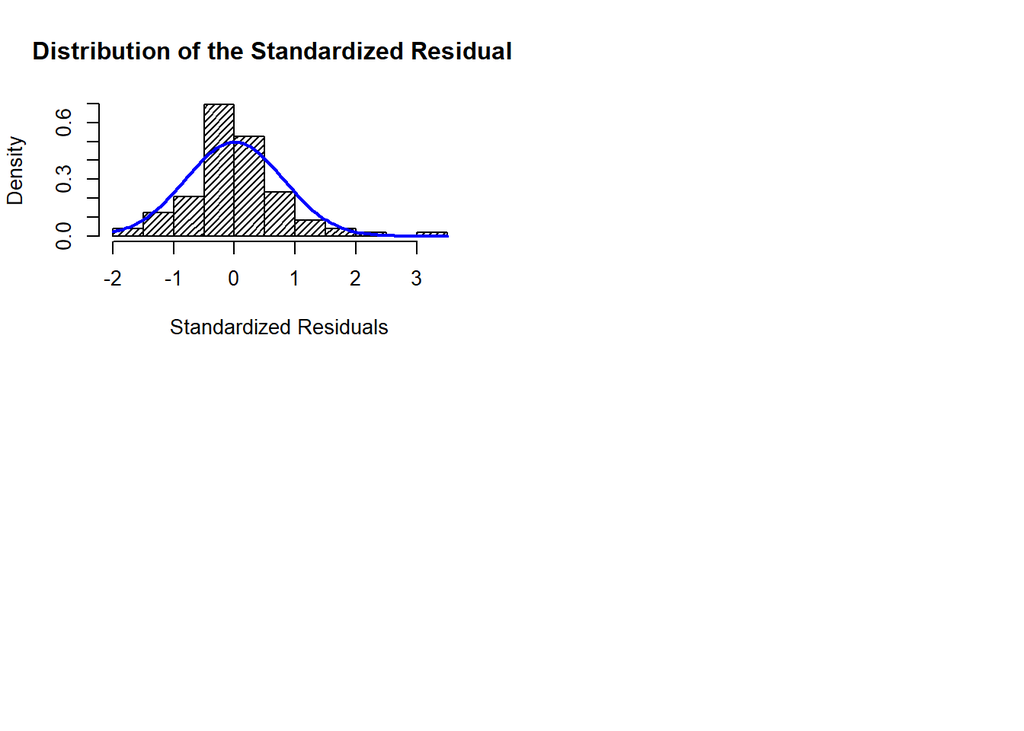

```r
## 2. Histogram of the standardized residuals
hist(resid(LMM_mctq_SJL, scaled = T),
     density = 30, col = "black",
     main = "Distribution of the Standardized Residuals",
     xlab = "Standardized Residuals",
     prob = T)
curve(dnorm(x, mean = mean(resid(LMM_mctq_SJL, scaled = T)),
            sd = sd(resid(LMM_mctq_SJL, scaled = T))),
      col = "blue", lwd = 2, add = T, yaxt="n")
```

## 5.2 Effect Sizes

Cohen’s d was calculated to estimate the effect size. For detailed explanation about the effect size and the formula used in the function, please refer to the report section 2.4.3 Cohen’s d.

```r
#######################################
### Function to calculate Cohen's d ###
######################################

cohend_morris = function(post_t, pre_t, post_c, pre_c) {
  #order: post treatment, pre treatment, post control, pre control

  #calculate cp
  nT = as.numeric(length(post_t)) + as.numeric(length(pre_t))

  nC = as.numeric(length(pre_c)) + as.numeric(length(post_c))

  c_p = 1 - 3/(4*(nT+nC-2)-1)

  #calculate pooled SD at the baseline: SDpre
  ##requires SDpre,T, SDpre,C
  SD_pre_T = sd(as.numeric(pre_t))
  SD_pre_C = sd(as.numeric(pre_c))
  SD_pre_pooled = sqrt(((nT-1)*SD_pre_T^2 + (nC-1)*SD_pre_C^2)/(nT+nC-2))

  ##final d
  d_morris = c_p*((mean(post_t) - mean(pre_t))-(mean(post_c)-mean(pre_c)))/SD_pre_pooled

  return(d_morris)
}
```

```r
# Datasets without NA's
data_pre_t <- df_pretest_Q[complete.cases(df_pretest_Q), ]
data_post_t <- df_Q_post_final[complete.cases(df_Q_post_final), ]
data_pre_c <- df_controlpre_Q[complete.cases(df_controlpre_Q), ]
data_post_c <-  df_controlpost_Q[complete.cases(df_controlpost_Q), ]

# Dataframe including all the effect sizes
df_effectsizes <- data.frame(ISI = round(cohend_morris(post_t = data_post_t$ISI_total,
                               pre_t = data_pre_t$ISI_total,
                               post_c = data_post_c$ISI_total,
                               pre_c = data_pre_c$ISI_total), 2),

                 PHQ = round(cohend_morris(post_t = data_post_t$PHQ_total,
                               pre_t = data_pre_t$PHQ_total,
                               post_c = data_post_c$PHQ_total,
                               pre_c = data_pre_c$PHQ_total), 2),

                 GAD = round(cohend_morris(post_t = data_post_t$GAD_total,
                               pre_t = data_pre_t$GAD_total,
                               post_c = data_post_c$GAD_total,
                               pre_c = data_pre_c$GAD_total), 2),

                 WSAS = round(cohend_morris(post_t = data_post_t$WSAS_total,
                               pre_t = data_pre_t$WSAS_total,
                               post_c = data_post_c$WSAS_total,
                               pre_c = data_pre_c$WSAS_total), 2),

                 MHQol = round(cohend_morris(post_t = data_post_t$MHQol_total,
                               pre_t = data_pre_t$MHQol_total,
                               post_c = data_post_c$MHQol_total,
                               pre_c = data_pre_c$MHQol_total), 2),

                  mtcq_SDweek = round(cohend_morris(post_t = as.numeric(data_post_t$mctq_SDweek),
                               pre_t = as.numeric(data_pre_t$mctq_SDweek),
                               post_c = as.numeric(data_post_c$mctq_SDweek),
                               pre_c = as.numeric(data_pre_c$mctq_SDweek )), 2),

                  mtcq_SLossWeek = round(cohend_morris(post_t = as.numeric(data_post_t$mctq_SLossWeek),
                               pre_t = as.numeric(data_pre_t$mctq_SLossWeek),
                               post_c = as.numeric(data_post_c$mctq_SLossWeek),
                               pre_c = as.numeric(data_pre_c$mctq_SLossWeek)), 2),

                 mtcq_SJL= round(cohend_morris(post_t = as.numeric(data_post_t$mctq_SJL),
                               pre_t = as.numeric(data_pre_t$mctq_SJL),
                               post_c = as.numeric(data_post_c$mctq_SJL),
                               pre_c = as.numeric(data_pre_c$mctq_SJL)), 2)

                 )
```

```r
df_effectsizes
```

```
##     ISI   PHQ   GAD  WSAS MHQol mtcq_SDweek mtcq_SLossWeek mtcq_SJL
## 1 -1.62 -1.27 -0.54 -0.76  0.21       -0.21          -0.57     1.17
```

# 6. Extra: Interaction plots

## 6.1 ISI plots

```r
test_data2 <- test_data
levels(test_data2$treatment) <- c("control", "dCBTi")
levels(test_data2$time) <- c("pre", "post")
```

```r
test_data2[test_data2$treatment == 1, 11] <- "control"
test_data2[test_data2$treatment == 2, 11] <- "dCBTi"

test_data2[test_data2$time == 1, 10] <- "pre"
test_data2[test_data2$time == 2, 10] <- "post"
```

```r
# Fitting the model
LMM_ISI2 <- lmer(ISI_total ~ treatment + time +  treatment:time +  ( 1|ID_reg),
               data = test_data2,
               REML = T)
```

```r
library(emmeans)
```

```r
ISI_plot <- emmip(LMM_ISI2, treatment ~ time,
  cov.keep = 3, at = list(),
  CIs = TRUE, level = 0.95, position = "jitter",
  xlab = "Time of Measurement",
  ylab = "ISI Total-Score")
```

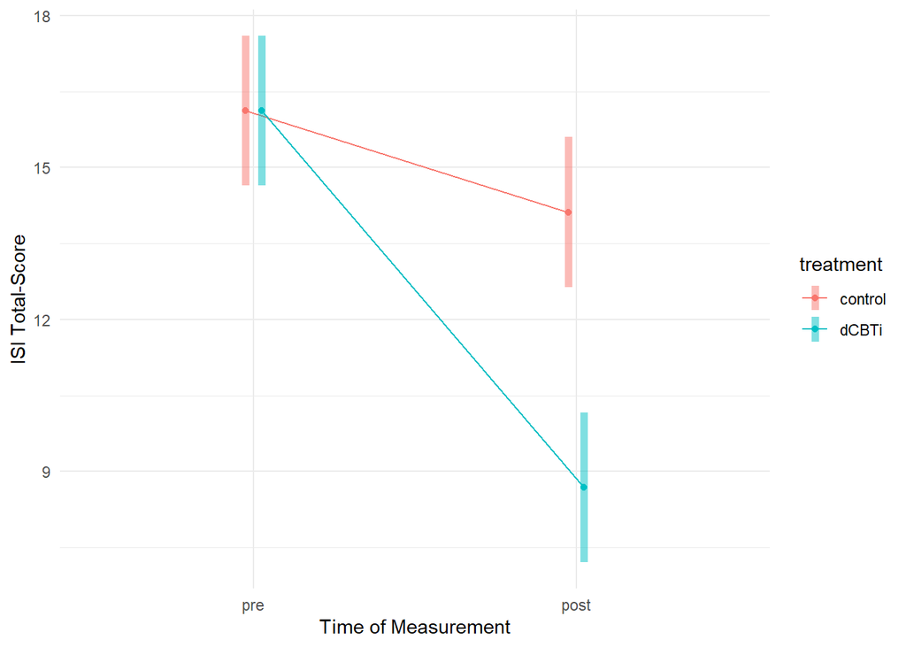

```r
library(ggplot2)
ISI_plot + theme_minimal()
```

## 6.2 GAD plots

```r
# Fitting the model
LMM_GAD2 <- lmer(GAD_total ~ treatment + time +  treatment:time +  ( 1|ID_reg),
               data = test_data2,
               REML = T)
```

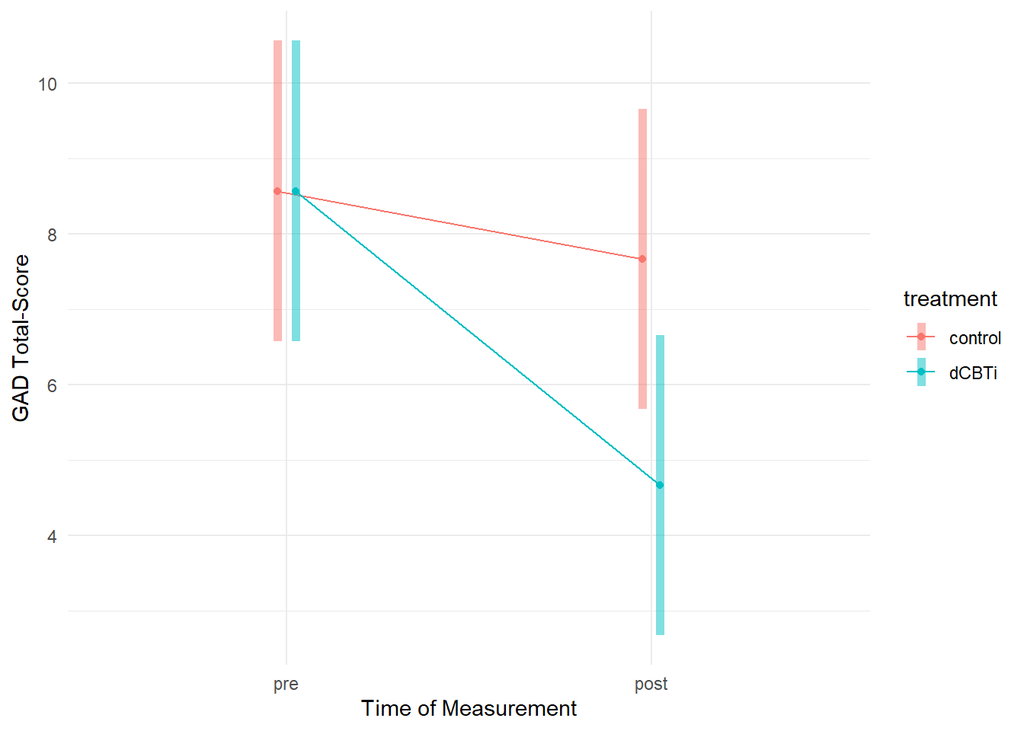

```r
library(emmeans)
library(ggplot2)

GAD_plot <- emmip(LMM_GAD2, treatment ~ time,
  cov.keep = 3, at = list(),
  CIs = TRUE, level = 0.95, position = "jitter",
  xlab = "Time of Measurement",
  ylab = "GAD Total-Score")

GAD_plot + theme_minimal()
```